# Logistic Regression Assignment

Xuhao Dong

## Logistic Regression

Logistic regression allows us to apply the power of regression to cases where our outcome variable is binary (0/1). The fitting process and coefficient interpretation are quite a bit different from linear regression. The technique is powerful and pretty ubiquitous in business, where there are many problems with binary outcomes (e.g., purchasing, re-purchasing, customer attrition, etc.)

## Instructions

Follow along in this document. There are places where I’ve added comments encouraging you to do analyses, make plots, etc. In the modeling section I’ve asked you to build a logistic regression model and in the interpretation section I’ve asked you to interpret it. Do so, then knit your model and commit both your knitted HTML and your RMD.

## Data

The data for this project comes from a local company, TOMIS, who manages bookings, websites, and marketing for a variety of tour operators. They’ve graciously allowed us to use a sample of data on customer booking habits. The data is pretty large (~52 MB) and can be downloaded from Moodle. Once you’ve downloaded it, extract it from its zip file into this folder.

```r
input.data.file <- "trip_scoring_data.txt"

d <- read_tsv(input.data.file)
```

The data set has the following columns:

1. `id`: a unique identifier for the customer.
2. `total_spent`: the amount of money the customer has spent with the tour operator.
3. `days_since_last`: the number of days since the last time the customer booked with this operator.
4. `bookings_in_last_13_months`: the number of bookings in the preceding 13 months.
5. `bookings_in_13_to_26_months`: the number of bookings 13 to 26 months ago.
6. `bookings_more_than_26_months`: the number of bookings more than 26 months ago.
7. `mean_dist_to_client_location`: the mean distance from the customer to the tour operator. This is missing for about 35% of rows.
8. `mean_leading_days`: the mean number of days that the customer books their experiences.
9. `mean_rebook_days`: if the customer rebooks, the mean number of days between those rebookings.
10. `booking_dt`: the calendar date and time of the booking.
11. `experience_dt`: the calendar date and time of the experience, which is what the tours or trips are called.
12. `client`: There are 14 clients in the data set. These are the tour operators.
13. `client_location`: Some clients have multiple locations. This field allows us to differentiate between them.
14. `guests`: The number of people on the experience.
15. `domain`: the web domain of the customer’s email.
16. `rebooked`: our response variable. Zero or one depending on whether or not the customer rebooks. There are 12.4% of rows that have rebookings.

## Data Exploration

Let’s take a look at rebooking rates by client:

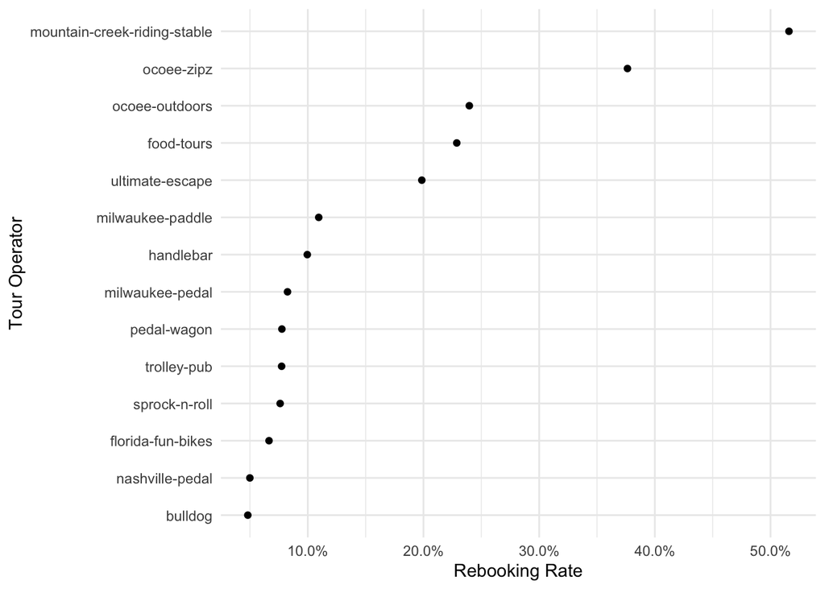

```r
d %>%
  group_by(client) %>%
  summarize(mean_rebook = mean(rebooked)) %>%
  mutate(client = fct_reorder(client,mean_rebook)) %>%
  ggplot(aes(x=mean_rebook,y=client)) +
  geom_point() +
  theme_minimal() +
  labs(x="Rebooking Rate",
       y="Tour Operator") +
  scale_x_continuous(label=percent)
```

As we can see, there’s quite a bit of variability in rebooking rates across clients. Therefore, client is likely to be a useful explanatory variable in our model.

## Model

```r
d <- d %>%
  mutate(client_fct = fct_reorder(client,rebooked,mean))

glm.1 <- glm(rebooked ~ client_fct +
                    total_spent+ mean_leading_days,
                  data=d %>% slice_sample(prop=0.5),
                  family="binomial",
                  subset=total_spent < 20000)

rb.fit <- tidy(glm.1) %>%
  mutate(exp_estimate = exp(estimate),
         lb = exp(estimate - 2*std.error),
         ub = exp(estimate + 2*std.error)) %>%
  mutate(pretty_term = if_else(grepl("client",term),
                               gsub("client_fct","",term),
                               term))
summary(glm.1)
```

```
##
## Call:
## glm(formula = rebooked ~ client_fct + total_spent + mean_leading_days,
##     family = "binomial", data = d %>% slice_sample(prop = 0.5),
##     subset = total_spent < 20000)
##
## Deviance Residuals:
##     Min       1Q   Median       3Q      Max
## -2.5734  -0.4211  -0.3500  -0.3044   2.5950
##
## Coefficients:
##                                          Estimate Std. Error z value Pr(>|z|)
## (Intercept)                            -3.066e+00  3.358e-02 -91.291  < 2e-16
## client_fctnashville-pedal              -2.660e-01  4.734e-02  -5.618 1.93e-08
## client_fctflorida-fun-bikes            -1.441e-02  3.454e-01  -0.042    0.967
## client_fctsprock-n-roll                 2.249e-01  1.187e-01   1.896    0.058
## client_fcttrolley-pub                   3.719e-01  4.978e-02   7.471 7.96e-14
## client_fctpedal-wagon                   3.105e-01  5.153e-02   6.025 1.69e-09
## client_fctmilwaukee-pedal               2.949e-01  6.022e-02   4.897 9.74e-07
## client_fcthandlebar                     4.051e-01  5.171e-02   7.833 4.76e-15
## client_fctmilwaukee-paddle              4.815e-01  9.394e-02   5.125 2.97e-07
## client_fctultimate-escape               1.542e+00  4.289e-02  35.942  < 2e-16
## client_fctfood-tours                    1.542e+00  7.474e-02  20.628  < 2e-16
## client_fctocoee-outdoors                1.675e+00  7.450e-02  22.487  < 2e-16
## client_fctocoee-zipz                    2.296e+00  8.641e-02  26.571  < 2e-16
## client_fctmountain-creek-riding-stable  2.988e+00  4.167e-02  71.701  < 2e-16
## total_spent                             6.806e-04  3.303e-05  20.607  < 2e-16
## mean_leading_days                       4.123e-03  4.116e-04  10.019  < 2e-16
##
## (Intercept)                            ***
## client_fctnashville-pedal              ***
## client_fctflorida-fun-bikes
## client_fctsprock-n-roll                .
## client_fcttrolley-pub                  ***
## client_fctpedal-wagon                  ***
## client_fctmilwaukee-pedal              ***
## client_fcthandlebar                    ***
## client_fctmilwaukee-paddle             ***
## client_fctultimate-escape              ***
## client_fctfood-tours                   ***
## client_fctocoee-outdoors               ***
## client_fctocoee-zipz                   ***
## client_fctmountain-creek-riding-stable ***
## total_spent                            ***
## mean_leading_days                      ***
## ---
## Signif. codes:  0 '***' 0.001 '**' 0.01 '*' 0.05 '.' 0.1 ' ' 1
##
## (Dispersion parameter for binomial family taken to be 1)
##
##     Null deviance: 71172  on 101123  degrees of freedom
## Residual deviance: 60095  on 101108  degrees of freedom
## AIC: 60127
##
## Number of Fisher Scoring iterations: 5
```

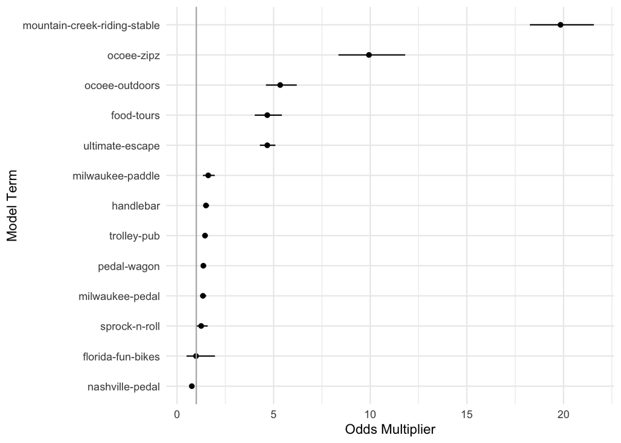

```r
ggplot(rb.fit %>%
         filter(grepl("client",term)) %>%
         mutate(pretty_term = fct_reorder(pretty_term,exp_estimate)),
       aes(x=exp_estimate,y=pretty_term)) +
  geom_point() +
  geom_errorbarh(aes(xmin=lb,xmax=ub,y=pretty_term),
                 height=0) +
  theme_minimal() +
  labs(x="Odds Multiplier",
       y="Model Term") +
  geom_vline(xintercept=1,col="gray70")
```

## Accuracy

```r
  holdout.d <- d %>%
    slice_sample(prop=0.1) %>%
    select(id,rebooked)

  glm.test <- update(glm.1,subset=!(id %in% holdout.d$id))

  holdout.d <- holdout.d %>%
    mutate(predicted_val = predict(glm.1,
                                   newdata=d %>%
                                     filter(id %in% holdout.d$id)))
  holdout.d <- holdout.d %>%
    mutate(est_rebooked = as.numeric(predicted_val >= 0.5))

  confusion.mat <- table(holdout.d$rebooked,holdout.d$est_rebooked)

  rownames(confusion.mat) <- c("Didn't Rebook","Did Rebook")
  colnames(confusion.mat) <- c("Pred No Rebook","Pred Rebook")

  knitr::kable(confusion.mat)
```

|  | Pred No Rebook | Pred Rebook |
| --- | --- | --- |
| Didn’t Rebook | 17992 | 46 |
| Did Rebook | 2182 | 4 |

The model is somewhat accurate at predict note-rebooking, but overall the model is not on point with predicting the people who are willing to rebook. Therefore, the model can be better.